# Assignment 11

```python
import pandas as pd
import seaborn as sns
```

```python
penguins = sns.load_dataset('penguins')
penguins.head()
```

|  | species | island | bill_length_mm | bill_depth_mm | flipper_length_mm | body_mass_g | sex |
| --- | --- | --- | --- | --- | --- | --- | --- |
| 0 | Adelie | Torgersen | 39.1 | 18.7 | 181.0 | 3750.0 | Male |
| 1 | Adelie | Torgersen | 39.5 | 17.4 | 186.0 | 3800.0 | Female |
| 2 | Adelie | Torgersen | 40.3 | 18.0 | 195.0 | 3250.0 | Female |
| 3 | Adelie | Torgersen | NaN | NaN | NaN | NaN | NaN |
| 4 | Adelie | Torgersen | 36.7 | 19.3 | 193.0 | 3450.0 | Female |

```python
penguins.groupby('island').mean()
```

| island | bill_length_mm | bill_depth_mm | flipper_length_mm | body_mass_g |
| --- | --- | --- | --- | --- |
| Biscoe | 45.257485 | 15.874850 | 209.706587 | 4716.017964 |
| Dream | 44.167742 | 18.344355 | 193.072581 | 3712.903226 |
| Torgersen | 38.950980 | 18.429412 | 191.196078 | 3706.372549 |

### Diference

Ja er is een klein verschil tussen de waardes vergeleken met andere eilanden.

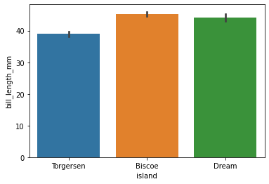

```python
sns.barplot(y='bill_length_mm', x='island', data=penguins)
```

Over bovenstaande grafiek is weinig te zeggen. Alleen de penguins van het Torgersen eiland hebben kortere snavels. de Biscoe en Dream kan je niet met elkaar vergelijken want de Coincidence interval overlappen elkaar. dus alleen over Torgersen is valt er iets over te zeggen.

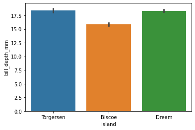

```python
sns.barplot(y='bill_depth_mm', x='island', data=penguins)
```

Zoals bij de vorrige grafiek beschreven. overlappen deze keer de Torgersen en Dream bar. daarom kan je allen zeggen dat de Biscoe island een mindere Bill Depth heeft.

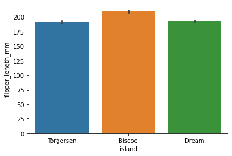

```python
sns.barplot(y='flipper_length_mm', x='island', data=penguins)
```

Hier is opnieuw duidelijk dat er vrijwel geen verschil is tussen de Torgersen- en Dream-penguins, maar de Biscoe-penguins steken opnieuw af. Deze keer zijn hun flippers echter langer dan die van de andere eilanden.

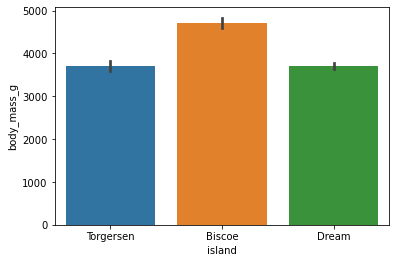

```python
sns.barplot(y='body_mass_g', x='island', data=penguins)
```

hier is er wel een duidelijk verschil dat de Biscoe island penguins een hogere body mass index heeft.

# Conclusie